# More about Prior Distributions

HME Spring 2025

updated on 2025-02-12

> As scientists, we should always prefer to use appropriate, well-constructed, informative priors on $\theta$ - Hobbs & Hooten

# More about prior distributions

- Selecting priors is one of the more confusing and often contentious topics in Bayesian analyses.
- It is often confusing because there is no direct counterpart in traditional frequentist statistical training.
- It is controversial because modifying the prior will potentially modify the posterior.
- Many scientists are uneasy with the idea that you have to *choose* the prior.
- This imparts some subjectivity into the modeling workflow, which conflicts with the idea that we should be “objective” and only base our conclusions on what our data tell us.
- But this view is both philosophically counter to the scientific method and ignores the many benefits of using priors that contain some information about the parameter(s).

# A note on this material

- Best practices for selecting priors is an area of active research in the statistical literature, and advice in the ecological literature is changing rapidly.
- As a result, the following sections may be out-of-date in short order.
- Nonetheless, understanding how and why to construct priors will greatly benefit your analyses, so we need to spend some time on this topic.
- Lastly, thanks to Clark Rushing!

# Non-informative priors

# Non-informative priors

In much of the ecological literature the standard method of selecting priors is to choose priors that have minimal impact on the posterior distribution, so called **non-informative priors**  
NOTE: non-informative priors = *default* priors in Banner et al. 2020.

Using non-informative priors is intuitively appealing because:

- they let the data “do the talking” (WHAT DOES THIS MEAN???)
- they return posteriors that are generally consistent with frequentist-based analyses
- they are usually non-controversial in the current ecological literature

# Non-informative priors

Non-informative priors generally try to be agnostic about the prior probability of a given parameter, say, $\theta$

For example, if $\theta$ is a probability, $Uniform(0,1)$ gives equal prior probability to all possible values:

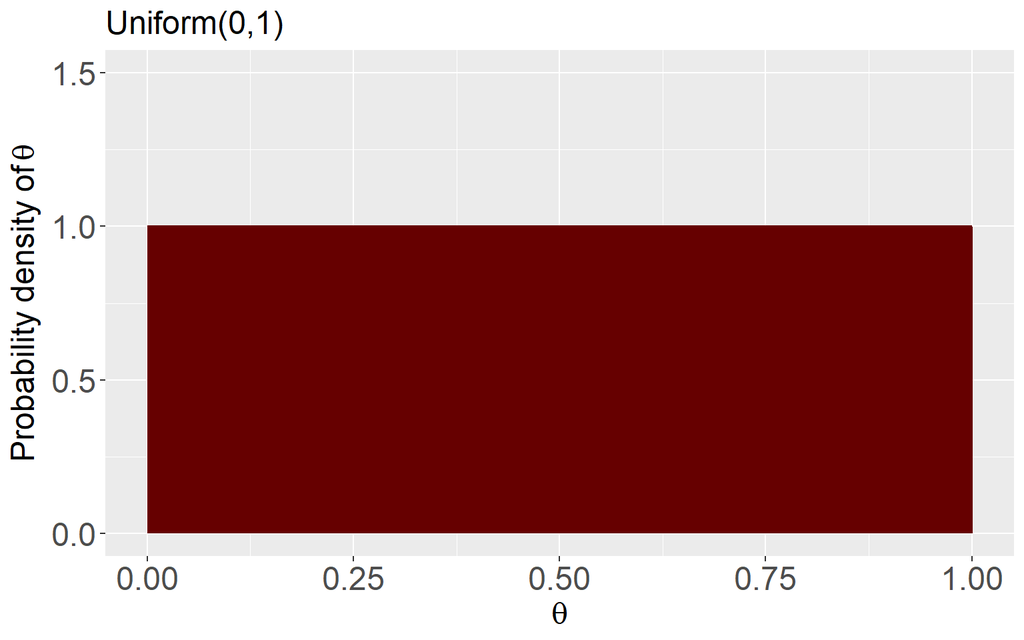

# Non-informative priors

As a side note, the $Uniform(0,1)$ is a special case of the beta distribution with $\alpha = \beta = 1$, so we can make the same plot using using $Beta(1,1)$

This is important because the $Beta$ distribution is a *conjugate* prior for the $Binomial$ distribution, which makes estimating the posterior a bit easier (more on this in a bit)

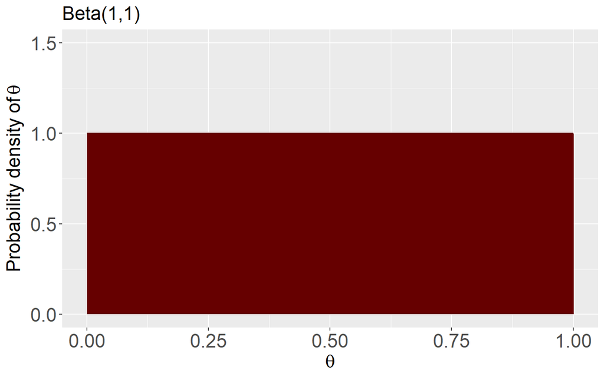

# Non-informative priors

For a parameter that could be any real number, a common choice is a normal prior with very large variance:

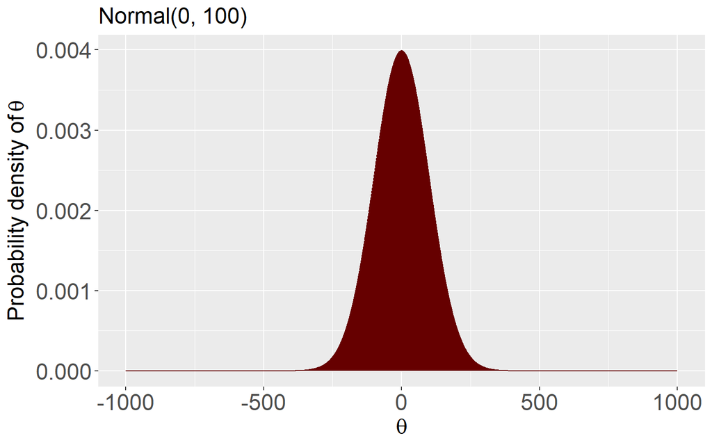

# Non-informative priors

Over realistic values of $\theta$, this distribution appears relatively flat:

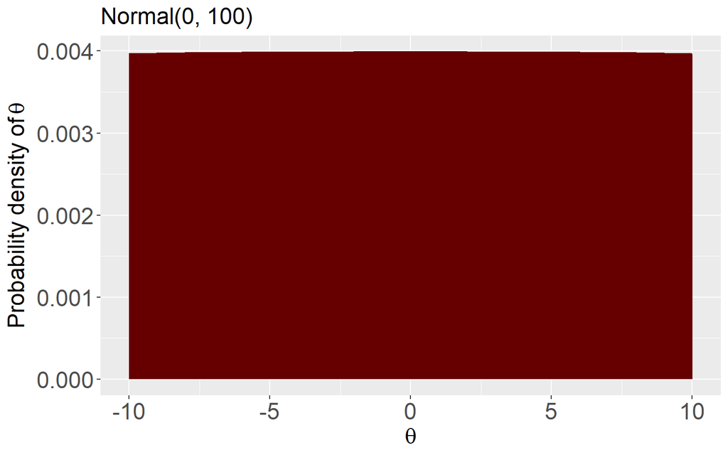

# Non-informative priors

Another way to think about it is consider the y-axis and the density at any given value:

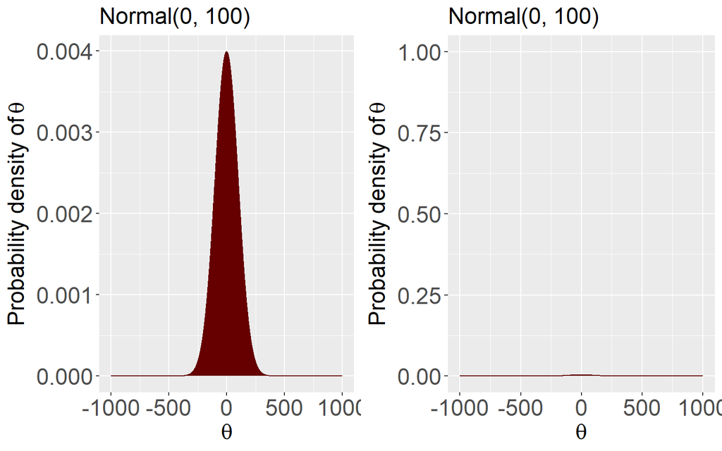

Hence being commonly referred to as “flat, uninformative priors”, although “default” is the preferred term and Banner et al. 2020 defines vague/flat differently.

# Non-informative priors

Often ecological models have parameters that are restricted to real values $>0$ (variance or standard deviation, for example)

In these cases, uniform priors from 0 to some large number (e.g., 100) are often used or sometimes very diffuse gamma priors, e.g. $gamma(0.01, 0.01)$

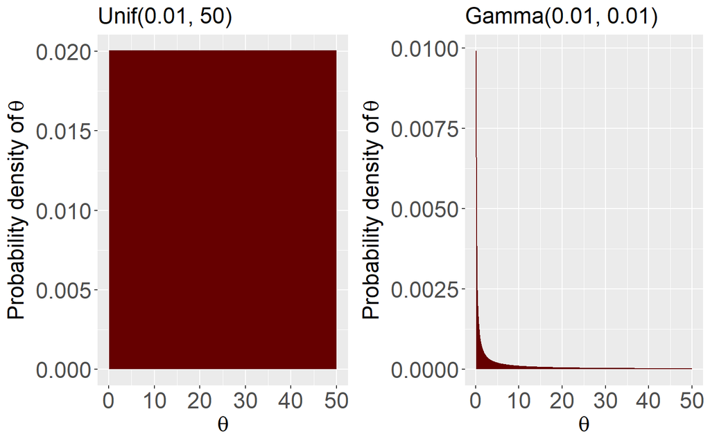

The gamma distribution may not *look* vague at first glance because most of the mass is near 0. But because the tail is very long, $gamma(0.01, 0.01)$ actually tells us very little about $\theta$. When either prior combined with data, the posterior distribution will be almost completely driven by the data.

# Non-informative priors

Non-informative priors are appealing because they appear to take the subjectivity out of our analysis $^1$ - they “let the data do the talking”

However, non-informative priors are often not the best choice for practical and philosophical reasons

$^1$ technically they are only “objective” if we all come up with the *same* vague priors

# Practical considerations with priors

The prior always has *some* influence on the posterior and in some cases can actually have quite a bit of influence

For example, let’s say we track 10 individuals over a period of time using GPS collars and we want to know the probability that an individual survives from time $t$ to time $t+1$ $^1$.

- assume 8 individuals died during our study (so two 1’s and eight 0’s)
- A natural model for these data is the binomial distribution with $N = 10$ and probability $p$
- Because $p$ is a parameter, it needs a prior:
  - $Beta(1,1)$ gives equal prior probability to all values of $p$ between 0 and 1

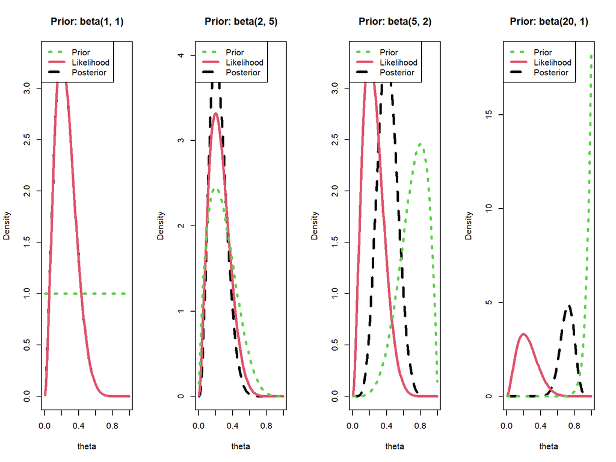

# Practical considerations with priors

Another potential issue to be aware of with non-informative priors is that they are not always non-informative if we have to transform them

For example, imagine we are modeling the probability that a species (e.g., a really nice frog) occupies a site, $p$, which ranges from 0-1 on the probability scale:
$$p \sim
Uniform(0,1)$$
This seems non-informative because it gives equal weight to all probabilities between 0 and 1.

However, we typically use the logit-transformed probability $logit(p)$, when we model $p$ as a function of covariates:
$$logit(p) \sim Normal(0, \sigma^2)$$
A $Uniform(0,1)$ prior on $p$ is **NOT** uniform on the logit scale. Instead, it becomes *highly informative*, heavily favoring values of $p$ near 0.5 and strongly downweighting values near the bounds of the parameter support (near 0 or 1)

The logit scale transforms the probability to a real number:

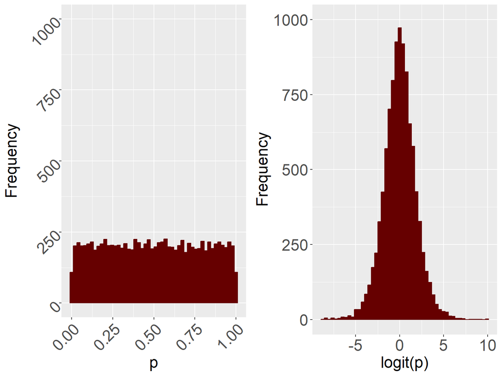

# (QUICKLY!) Conjugate priors

- Banner et al. 2020 defined and discussed conjugate priors: > “A prior distribution that has the same distributional form as the posterior distribution”

-A very common example is the beta-binomial distribtion. -It turns out when we have binomial likelihood and a beta prior, the posterior distribution will also be a beta distribution

This scenario, when the prior and the posterior have the same distribution, occurs when the likelihood and prior are **conjugate** distributions.

A few conjugate distributions

| Likelihood | Prior | Posterior |
| --- | --- | --- |
| $y_i \sim binomial(n, p)$ | $p \sim beta(\alpha, \beta)$ | $p \sim beta(\sum y_i + \alpha, n -\sum y_i + \beta)$ |
| $y_i \sim Bernoulli(p)$ | $p \sim beta(\alpha, \beta)$ | $p \sim beta(\sum_{i=1}^n y_i + \alpha, \sum_{i=1}^n (1-y_i) + \beta)$ |
| $y_i \sim Poisson(\lambda)$ | $\lambda \sim gamma(\alpha, \beta)$ | $\lambda \sim gamma(\alpha \sum_{i=1}^n y_i, \beta + n)$ |

# (QUICKLY!) Conjugate priors

Conjugate distributions are useful because we can estimate the posterior distribution algebraically. For example, assuming a prior of $Beta(1,1)$, the posterior distribution for $p$ is:

$$beta(a + y, b+ n-y)$$
, where a = 1 (from the prior), b = 1 (from the prior), y = 2 (survived), n - y = 8 (died)
Substituting the values,
$$beta(1+2, 1 + (10-2)) = beta(3, 9)$$
This means that after observing the data, the updated belief about the surival probability follows a beta(3,9), with an expected value of $p = 0.25$

In practice, though, with particularly difficult problems, model convergence, and the speed at which we iterate through the MCMC, will improve/increase when we have nice, conjugate priors in the model.

# Philosophical issues with non-informative priors

- Aside from the practical issues, there are several philosophical issues regarding the use of non-informative priors.
- Many of the justifications for using non-informative priors stem from the idea that we should aim to *reduce* the influence of the prior so our data “do the talking.”
- But even MLE methods are subjective—so avoiding Bayesian methods or choosing non-informative priors doesn’t make our analyses more “objective.”
- Worse, MLE methods often hide these assumptions from view, making our subjective decisions implicit rather than explicit.

*By choosing the likelihood distribution, we are making assumptions about the data generating process (choose a different distribution, get a different answer)

# Philosophical issues with non-informative priors

- Science advances through the accumulation of facts.
- We are trained as scientists to be skeptical about results that are at odds with previous information about a system.
- If we find an unusual pattern in our data, we would be (and should be) very skeptical about these results.
- What’s more plausible? These data really do contradict what we know about the system, or they were generated by chance events related to our finite sample size?
- Bayesian analysis is powerful because it provides a formal mathematical framework for combining previous knowledge with newly collected data.

*In this way, Bayesian methods are a mathematical representation of the scientific method

# Philosophical issues with non-informative priors

Why shouldn’t we use prior knowledge to improve our inferences?

> “Ignoring prior information you have is like selectively throwing away data before an analysis” (Hobbs & Hooten)

# Philosophical issues with non-informative priors

Another way to think about the prior is as a *hypothesis* about our system

This hypothesis could be based on previously collected data or our knowledge of the system

If we know a lot, this prior could contain a lot of information** * **

If we don’t know much, this prior could contain less information**^**

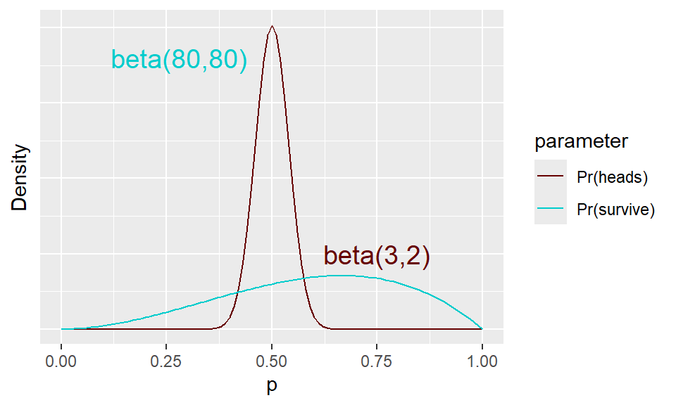

** * **for example, we’re pretty sure the probability of getting a heads in 50%

**^**we might not have great estimates of survival for our study organism but we know based on ecological theory and observed changes in abundance that it’s probably not *really* low

# Philosophical issues with non-informative priors

We allow our data to *update* this hypothesis

- Strong priors will require larger sample sizes and more informative data to change our beliefs about the system
- Less informative priors will require less data

This is how it should be - if we’re really confident in our knowledge of the system, we require very strong evidence to convince us otherwise

# Advantages of informative priors

So there are clearly philosophical advantages to using informative priors

But there are also a number of practical advantages:

1. Improved parameter estimates when sample sizes are small
- Making inferences from small samples sizes is exactly when we expect spurious results and poorly estimated parameters
- Priors are most influential when we have few data**^**
- The additional information about the parameters can reduce the chances that we base our conclusions on spurious results
- Informative priors can also reduce uncertainty in our parameter estimates and improve estimates of poorly identified parameters.

**^**Thinking about the beta distribution as previous coin flips, using an informative prior has the same effect as increasing sample size

# Advantages of informative priors

1. Improved parameter estimates when sample sizes are small
2. Stabilizing computational algorithms
- As models get more complex, the ratio of parameters to data grows
- As a result, we often end up with pathological problems related to parameter *identifiability***^**
- Informative priors can improve estimation by providing some structure to the parameter space explored by the fitting algorithm

**^**Basically, even with large sample sizes, the model cannot estimate all the parameters in the model

# Advantages of informative priors

1. Improved parameter estimates when sample sizes are small
2. Stabilizing computational algorithms

**Example**

If $y \sim Binomial(N, p)$ and the only data we have is $y$ (we don’t know $N$), we cannot estimate $N$ and $p$ no matter how much data we have**^**

Including information about either $N$ or $p$ via an informative prior can help estimate the other other parameter

**^** there are essentially unlimited combinations of $N$ and $p$ that are consistent with our data

# Advice on priors

1. Use non-informative priors as a starting point

> It’s fine to use non-informative priors as you develop your model but you should always prefer to use “appropriate, well-contructed informative priors” (Hobbs & Hooten)

# Advice on priors

1. Use non-informative priors as a starting point
2. Think hard

> Non-informative priors are easy to use because they are the default option. You can usually do better than non-informative priors but it requires thinking hard about the parameters in your model

# Advice on priors

1. Use non-informative priors as a starting point
2. Think hard
3. Use your “domain knowledge”

> We can often come up with weakly informative priors just be knowing something about the range of plausible values of our parameters

# Advice on priors

1. Use non-informative priors as a starting point
2. Think hard
3. Use your “domain knowledge”
4. Dive into the literature

> Find published estimates and convert into prior distributions

# Advice on priors

1. Use non-informative priors as a starting point
2. Think hard
3. Use your “domain knowledge”
4. Dive into the literature
5. Visualize your prior distribution

> Be sure to look at the prior in terms of the parameters you want to make inferences about (use simulation!)

# Advice on priors

1. Use non-informative priors as a starting point
2. Think hard
3. Use your “domain knowledge”
4. Dive into the literature
5. Visualize your prior distribution
6. Do a sensitivity analysis

> Does changing the prior change your posterior inference? If not, don’t sweat it. If it does, you’ll need to return to point 2 and justify your prior choice